# NBA Linear Regression

Nicholas Burke

17 June 2020

## Introduction

Simple linear regression is one of the most useful machine learning algorithm in the field of data science. To demonstrate its effectiveness, using data from the 2018-2019 NBA regular season, we will construct a linear regression model to determine a team’s wins projection based on their point differential over the course of the season. Upon further examination we will be able to determine the presence of and the strength of the relationship between these variables.

Using the ballr package in R, we will be able to extract NBA Team data from [basketballreference.com](https://www.basketball-reference.com/) directly into the console.

## NBA Statistics in R

Now that we have called all of the necessary dependencies. We can now view and use the final standings of the 2018-2019 NBA regular season.

NBA Standings

| eastern_conference | w | l | w_lpercent | gb | pw | pl | ps_g | pa_g |
| --- | --- | --- | --- | --- | --- | --- | --- | --- |
| Milwaukee Bucks* | 60 | 22 | 0.732 | — | 61 | 21 | 118.1 | 109.3 |
| Toronto Raptors* | 58 | 24 | 0.707 | 2.0 | 56 | 26 | 114.4 | 108.4 |
| Philadelphia 76ers* | 51 | 31 | 0.622 | 9.0 | 48 | 34 | 115.2 | 112.5 |
| Boston Celtics* | 49 | 33 | 0.598 | 11.0 | 52 | 30 | 112.4 | 108.0 |
| Indiana Pacers* | 48 | 34 | 0.585 | 12.0 | 50 | 32 | 108.0 | 104.7 |
| Orlando Magic* | 42 | 40 | 0.512 | 18.0 | 43 | 39 | 107.3 | 106.6 |
| Brooklyn Nets* | 42 | 40 | 0.512 | 18.0 | 41 | 41 | 112.2 | 112.3 |
| Detroit Pistons* | 41 | 41 | 0.500 | 19.0 | 40 | 42 | 107.0 | 107.3 |
| Charlotte Hornets | 39 | 43 | 0.476 | 21.0 | 38 | 44 | 110.7 | 111.8 |
| Miami Heat | 39 | 43 | 0.476 | 21.0 | 40 | 42 | 105.7 | 105.9 |
| Washington Wizards | 32 | 50 | 0.390 | 28.0 | 34 | 48 | 114.0 | 116.9 |
| Atlanta Hawks | 29 | 53 | 0.354 | 31.0 | 27 | 55 | 113.3 | 119.4 |
| Chicago Bulls | 22 | 60 | 0.268 | 38.0 | 21 | 61 | 104.9 | 113.4 |
| Cleveland Cavaliers | 19 | 63 | 0.232 | 41.0 | 19 | 63 | 104.5 | 114.1 |
| New York Knicks | 17 | 65 | 0.207 | 43.0 | 19 | 63 | 104.6 | 113.8 |

| western_conference | w | l | w_lpercent | gb | pw | pl | ps_g | pa_g |
| --- | --- | --- | --- | --- | --- | --- | --- | --- |
| Golden State Warriors* | 57 | 25 | 0.695 | — | 56 | 26 | 117.7 | 111.2 |
| Denver Nuggets* | 54 | 28 | 0.659 | 3.0 | 51 | 31 | 110.7 | 106.7 |
| Houston Rockets* | 53 | 29 | 0.646 | 4.0 | 53 | 29 | 113.9 | 109.1 |
| Portland Trail Blazers* | 53 | 29 | 0.646 | 4.0 | 51 | 31 | 114.7 | 110.5 |
| Utah Jazz* | 50 | 32 | 0.610 | 7.0 | 54 | 28 | 111.7 | 106.5 |
| Oklahoma City Thunder* | 49 | 33 | 0.598 | 8.0 | 50 | 32 | 114.5 | 111.1 |
| Los Angeles Clippers* | 48 | 34 | 0.585 | 9.0 | 43 | 39 | 115.1 | 114.3 |
| San Antonio Spurs* | 48 | 34 | 0.585 | 9.0 | 45 | 37 | 111.7 | 110.0 |
| Sacramento Kings | 39 | 43 | 0.476 | 18.0 | 38 | 44 | 114.2 | 115.3 |
| Los Angeles Lakers | 37 | 45 | 0.451 | 20.0 | 37 | 45 | 111.8 | 113.5 |
| Minnesota Timberwolves | 36 | 46 | 0.439 | 21.0 | 37 | 45 | 112.5 | 114.0 |
| Dallas Mavericks | 33 | 49 | 0.402 | 24.0 | 38 | 44 | 108.9 | 110.1 |
| New Orleans Pelicans | 33 | 49 | 0.402 | 24.0 | 38 | 44 | 115.4 | 116.8 |
| Memphis Grizzlies | 33 | 49 | 0.402 | 24.0 | 34 | 48 | 103.5 | 106.1 |
| Phoenix Suns | 19 | 63 | 0.232 | 38.0 | 19 | 63 | 107.5 | 116.8 |

A brief synopsis of each category’s abbreviations. Separated by

• w- number of team’s wins

• l- number of team’s losses

• w_lpercent – the team’s win loss percentage determine by number of wins divided by 82(total number of games played)

• ps_g- total team’s points scored per game

• ps_a- total team’s points allowed per game

• pw, pl will not be used in the project.

As indicated by the asterisks the top 8 teams of each conference makes the playoffs.

## Feature Engineer

In order to conduct some exploratory data analysis we will first to need to transform this data into a more manageable data frames.

First, let’s examine the structure of the data frame for the final standings for the 2018-2019 NBA season.

```
## List of 2
##  $ East:'data.frame':    15 obs. of  9 variables:
##   ..$ eastern_conference: chr [1:15] "Milwaukee Bucks*" "Toronto Raptors*" "Philadelphia 76ers*" "Boston Celtics*" ...
##   ..$ w                 : int [1:15] 60 58 51 49 48 42 42 41 39 39 ...
##   ..$ l                 : int [1:15] 22 24 31 33 34 40 40 41 43 43 ...
##   ..$ w_lpercent        : num [1:15] 0.732 0.707 0.622 0.598 0.585 0.512 0.512 0.5 0.476 0.476 ...
##   ..$ gb                : chr [1:15] "—" "2.0" "9.0" "11.0" ...
##   ..$ pw                : int [1:15] 61 56 48 52 50 43 41 40 38 40 ...
##   ..$ pl                : int [1:15] 21 26 34 30 32 39 41 42 44 42 ...
##   ..$ ps_g              : num [1:15] 118 114 115 112 108 ...
##   ..$ pa_g              : num [1:15] 109 108 112 108 105 ...
##  $ West:'data.frame':    15 obs. of  9 variables:
##   ..$ western_conference: chr [1:15] "Golden State Warriors*" "Denver Nuggets*" "Houston Rockets*" "Portland Trail Blazers*" ...
##   ..$ w                 : int [1:15] 57 54 53 53 50 49 48 48 39 37 ...
##   ..$ l                 : int [1:15] 25 28 29 29 32 33 34 34 43 45 ...
##   ..$ w_lpercent        : num [1:15] 0.695 0.659 0.646 0.646 0.61 0.598 0.585 0.585 0.476 0.451 ...
##   ..$ gb                : chr [1:15] "—" "3.0" "4.0" "4.0" ...
##   ..$ pw                : int [1:15] 56 51 53 51 54 50 43 45 38 37 ...
##   ..$ pl                : int [1:15] 26 31 29 31 28 32 39 37 44 45 ...
##   ..$ ps_g              : num [1:15] 118 111 114 115 112 ...
##   ..$ pa_g              : num [1:15] 111 107 109 110 106 ...
```

The schedules for each team are imbalanced with respect to their own conference, thus we will examine both the Eastern and the Western conferences separately.

Eastern Conference

| eastern_conference | w | l | w_lpercent | gb | pw | pl | ps_g | pa_g | pdf |
| --- | --- | --- | --- | --- | --- | --- | --- | --- | --- |
| Milwaukee Bucks* | 60 | 22 | 0.732 | — | 61 | 21 | 118.1 | 109.3 | 8.8 |
| Toronto Raptors* | 58 | 24 | 0.707 | 2.0 | 56 | 26 | 114.4 | 108.4 | 6.0 |
| Philadelphia 76ers* | 51 | 31 | 0.622 | 9.0 | 48 | 34 | 115.2 | 112.5 | 2.7 |
| Boston Celtics* | 49 | 33 | 0.598 | 11.0 | 52 | 30 | 112.4 | 108.0 | 4.4 |
| Indiana Pacers* | 48 | 34 | 0.585 | 12.0 | 50 | 32 | 108.0 | 104.7 | 3.3 |
| Orlando Magic* | 42 | 40 | 0.512 | 18.0 | 43 | 39 | 107.3 | 106.6 | 0.7 |
| Brooklyn Nets* | 42 | 40 | 0.512 | 18.0 | 41 | 41 | 112.2 | 112.3 | -0.1 |
| Detroit Pistons* | 41 | 41 | 0.500 | 19.0 | 40 | 42 | 107.0 | 107.3 | -0.3 |
| Charlotte Hornets | 39 | 43 | 0.476 | 21.0 | 38 | 44 | 110.7 | 111.8 | -1.1 |
| Miami Heat | 39 | 43 | 0.476 | 21.0 | 40 | 42 | 105.7 | 105.9 | -0.2 |
| Washington Wizards | 32 | 50 | 0.390 | 28.0 | 34 | 48 | 114.0 | 116.9 | -2.9 |
| Atlanta Hawks | 29 | 53 | 0.354 | 31.0 | 27 | 55 | 113.3 | 119.4 | -6.1 |
| Chicago Bulls | 22 | 60 | 0.268 | 38.0 | 21 | 61 | 104.9 | 113.4 | -8.5 |
| Cleveland Cavaliers | 19 | 63 | 0.232 | 41.0 | 19 | 63 | 104.5 | 114.1 | -9.6 |
| New York Knicks | 17 | 65 | 0.207 | 43.0 | 19 | 63 | 104.6 | 113.8 | -9.2 |

Western Conference

| western_conference | w | l | w_lpercent | gb | pw | pl | ps_g | pa_g | pdf |
| --- | --- | --- | --- | --- | --- | --- | --- | --- | --- |
| Golden State Warriors* | 57 | 25 | 0.695 | — | 56 | 26 | 117.7 | 111.2 | 6.5 |
| Denver Nuggets* | 54 | 28 | 0.659 | 3.0 | 51 | 31 | 110.7 | 106.7 | 4.0 |
| Houston Rockets* | 53 | 29 | 0.646 | 4.0 | 53 | 29 | 113.9 | 109.1 | 4.8 |
| Portland Trail Blazers* | 53 | 29 | 0.646 | 4.0 | 51 | 31 | 114.7 | 110.5 | 4.2 |
| Utah Jazz* | 50 | 32 | 0.610 | 7.0 | 54 | 28 | 111.7 | 106.5 | 5.2 |
| Oklahoma City Thunder* | 49 | 33 | 0.598 | 8.0 | 50 | 32 | 114.5 | 111.1 | 3.4 |
| Los Angeles Clippers* | 48 | 34 | 0.585 | 9.0 | 43 | 39 | 115.1 | 114.3 | 0.8 |
| San Antonio Spurs* | 48 | 34 | 0.585 | 9.0 | 45 | 37 | 111.7 | 110.0 | 1.7 |
| Sacramento Kings | 39 | 43 | 0.476 | 18.0 | 38 | 44 | 114.2 | 115.3 | -1.1 |
| Los Angeles Lakers | 37 | 45 | 0.451 | 20.0 | 37 | 45 | 111.8 | 113.5 | -1.7 |
| Minnesota Timberwolves | 36 | 46 | 0.439 | 21.0 | 37 | 45 | 112.5 | 114.0 | -1.5 |
| Dallas Mavericks | 33 | 49 | 0.402 | 24.0 | 38 | 44 | 108.9 | 110.1 | -1.2 |
| New Orleans Pelicans | 33 | 49 | 0.402 | 24.0 | 38 | 44 | 115.4 | 116.8 | -1.4 |
| Memphis Grizzlies | 33 | 49 | 0.402 | 24.0 | 34 | 48 | 103.5 | 106.1 | -2.6 |
| Phoenix Suns | 19 | 63 | 0.232 | 38.0 | 19 | 63 | 107.5 | 116.8 | -9.3 |

Let’s take a closer look at the of the Eastern and Western conference data structures.

Eastern Confernce

|  | eastern_conference | w | l | w_lpercent | gb | pw | pl | ps_g | pa_g | pdf |
| --- | --- | --- | --- | --- | --- | --- | --- | --- | --- | --- |
|  | Length:15 | Min. :17.0 | Min. :22.0 | Min. :0.2070 | Length:15 | Min. :19.00 | Min. :21.00 | Min. :104.5 | Min. :104.7 | Min. :-9.6000 |
|  | Class :character | 1st Qu.:30.5 | 1st Qu.:33.5 | 1st Qu.:0.3720 | Class :character | 1st Qu.:30.50 | 1st Qu.:33.00 | 1st Qu.:106.3 | 1st Qu.:107.7 | 1st Qu.:-4.5000 |
|  | Mode :character | Median :41.0 | Median :41.0 | Median :0.5000 | Mode :character | Median :40.00 | Median :42.00 | Median :110.7 | Median :111.8 | Median :-0.2000 |
|  | NA | Mean :39.2 | Mean :42.8 | Mean :0.4781 | NA | Mean :39.27 | Mean :42.73 | Mean :110.2 | Mean :111.0 | Mean :-0.8067 |
|  | NA | 3rd Qu.:48.5 | 3rd Qu.:51.5 | 3rd Qu.:0.5915 | NA | 3rd Qu.:49.00 | 3rd Qu.:51.50 | 3rd Qu.:113.7 | 3rd Qu.:113.6 | 3rd Qu.: 3.0000 |
|  | NA | Max. :60.0 | Max. :65.0 | Max. :0.7320 | NA | Max. :61.00 | Max. :63.00 | Max. :118.1 | Max. :119.4 | Max. : 8.8000 |

Western Conference

|  | western_conference | w | l | w_lpercent | gb | pw | pl | ps_g | pa_g | pdf |
| --- | --- | --- | --- | --- | --- | --- | --- | --- | --- | --- |
|  | Length:15 | Min. :19.0 | Min. :25.0 | Min. :0.2320 | Length:15 | Min. :19.00 | Min. :26.00 | Min. :103.5 | Min. :106.1 | Min. :-9.3000 |
|  | Class :character | 1st Qu.:34.5 | 1st Qu.:30.5 | 1st Qu.:0.4205 | Class :character | 1st Qu.:37.50 | 1st Qu.:31.00 | 1st Qu.:111.2 | 1st Qu.:109.5 | 1st Qu.:-1.4500 |
|  | Mode :character | Median :48.0 | Median :34.0 | Median :0.5850 | Mode :character | Median :43.00 | Median :39.00 | Median :112.5 | Median :111.1 | Median : 0.8000 |
|  | NA | Mean :42.8 | Mean :39.2 | Mean :0.5219 | NA | Mean :42.93 | Mean :39.07 | Mean :112.3 | Mean :111.5 | Mean : 0.7867 |
|  | NA | 3rd Qu.:51.5 | 3rd Qu.:47.5 | 3rd Qu.:0.6280 | NA | 3rd Qu.:51.00 | 3rd Qu.:44.50 | 3rd Qu.:114.6 | 3rd Qu.:114.2 | 3rd Qu.: 4.1000 |
|  | NA | Max. :57.0 | Max. :63.0 | Max. :0.6950 | NA | Max. :56.00 | Max. :63.00 | Max. :117.7 | Max. :116.8 | Max. : 6.5000 |

## Exploratory Data Analysis

An analysis will be conducted to determine the accuracy and strength of the relationship between wins and point differential.

Graph these two variable in the respective conferences will result in the following scatter plots.

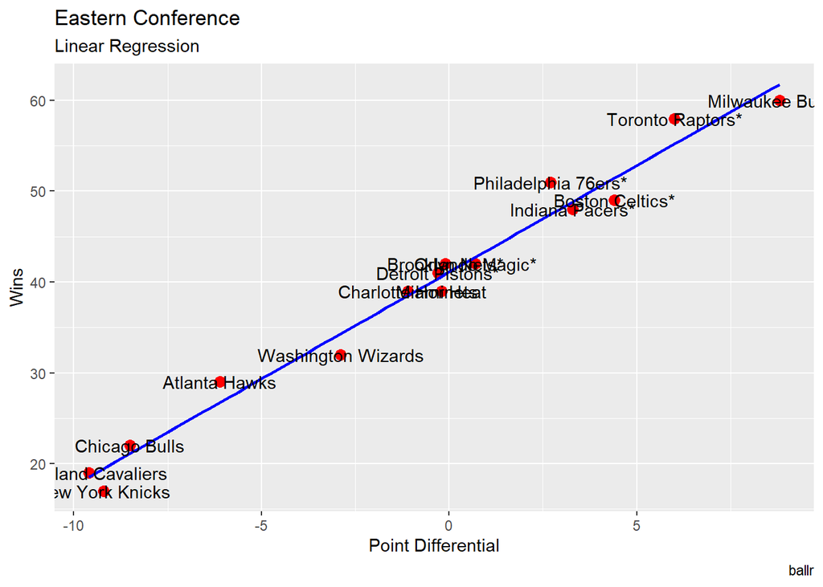

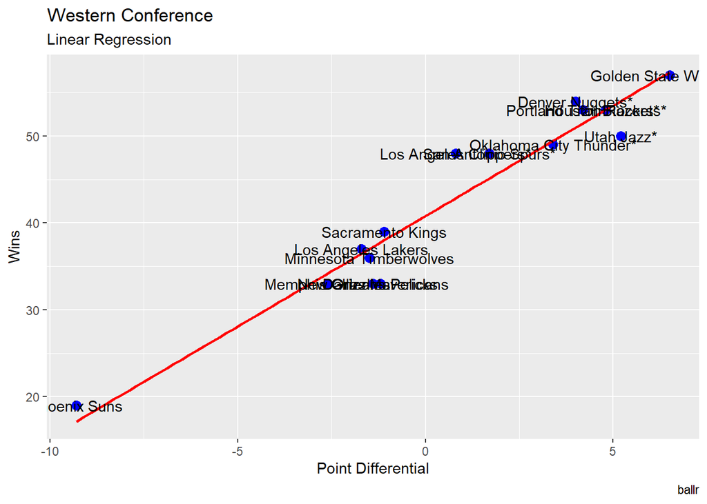

As you can see there is a clear linear relationship between point differential and wins for both conferences.

Below is the numerical correlation between point differential and wins.

Eastern Conference

|  | pdf | w |
| --- | --- | --- |
| pdf | 1.0000000 | 0.9892606 |
| w | 0.9892606 | 1.0000000 |

Western Conference

|  | pdf | w |
| --- | --- | --- |
| pdf | 1.0000000 | 0.9654652 |
| w | 0.9654652 | 1.0000000 |

As expected there is a strong linear relationship between these two variables. Linear regression is the best way to predict how many wins a team will have given the point differential.

## Linear Regression Model To Predict Wins

We can now start to build our linear regression model, first we will need to create a training set and a testing set for both the Eastern and Western Conference data.

### Train and Test Data

We will split the data accordingly, in order to test the accuracy of our model.

We will use the lm() function to fit a simple linear regression lm() model. The simple syntax for lm(y∼x,data), where y is the response variable wins , x is the predictor variable point differential. We will construction a simple linear regression model for both conferences.

For the Western Conference

```
##
## Call:
## lm(formula = w ~ pdf, data = Wtrain)
##
## Residuals:
##     Min      1Q  Median      3Q     Max
## -4.5033 -1.0871 -0.5612  1.5801  3.9548
##
## Coefficients:
##             Estimate Std. Error t value Pr(>|t|)
## (Intercept)  42.1437     0.8281   50.89 2.46e-11 ***
## pdf           2.3768     0.1813   13.11 1.09e-06 ***
## ---
## Signif. codes:  0 '***' 0.001 '**' 0.01 '*' 0.05 '.' 0.1 ' ' 1
##
## Residual standard error: 2.498 on 8 degrees of freedom
## Multiple R-squared:  0.9555, Adjusted R-squared:   0.95
## F-statistic: 171.8 on 1 and 8 DF,  p-value: 1.09e-06
```

For the Eastern Conference

```
##
## Call:
## lm(formula = w ~ pdf, data = Etrain)
##
## Residuals:
##     Min      1Q  Median      3Q     Max
## -2.1766 -1.1911 -0.3647  1.1894  2.9488
##
## Coefficients:
##             Estimate Std. Error t value Pr(>|t|)
## (Intercept)  40.5214     0.5834   69.46 2.05e-12 ***
## pdf           2.4216     0.1216   19.92 4.21e-08 ***
## ---
## Signif. codes:  0 '***' 0.001 '**' 0.01 '*' 0.05 '.' 0.1 ' ' 1
##
## Residual standard error: 1.783 on 8 degrees of freedom
## Multiple R-squared:  0.9802, Adjusted R-squared:  0.9778
## F-statistic: 396.6 on 1 and 8 DF,  p-value: 4.212e-08
```

### Interpretation

The R-squared values is the proportion of variance explained and so it always takes on a value between 0 and 1, and is independent of the scale of Y. Getting values of 0.9555 and 0.9802 are very high indicating that our model fits well.

### Prediction

Lastly, we will test our model using our test set for each conference to see how well our wins projection compares to the actual amount.

Eastern Conference

|  | Team | Projected | Actual |
| --- | --- | --- | --- |
| 3 | Philadelphia 76ers* | 47.0597978990053 | 51 |
| 11 | Washington Wizards | 33.4986630456518 | 32 |
| 12 | Atlanta Hawks | 25.7494431294497 | 29 |
| 13 | Chicago Bulls | 19.9375281922982 | 22 |
| 14 | Cleveland Cavaliers | 17.2737338461038 | 19 |

Western Conference

|  | Team | Projected | Actual |
| --- | --- | --- | --- |
| 3 | Houston Rockets* | 53.5525308020923 | 53 |
| 11 | Minnesota Timberwolves | 38.578494634984 | 36 |
| 12 | Dallas Mavericks | 39.2915439762749 | 33 |
| 13 | New Orleans Pelicans | 38.8161777487477 | 33 |
| 14 | Memphis Grizzlies | 35.9639803835842 | 33 |

Here are some summary statistics for our linear regression model.

### Sum of Squared Errors

SSE is the measure of the discrepancy between the data and an estimation model.

For the Eastern Conference

```
## [1] 25.43554
```

For the Western Conference

```
## [1] 49.92625
```

### Root Mean Squared Error

RMSE is used to measure the differences between values predicted by a model or an estimator and the values observed.

For the Eastern Conference

```
## [1] 1.302191
```

For the Western Conference

```
## [1] 1.824395
```